# Final Project - 3 Point Percentage (3) - ACTUAL FINAL

For a team to determine who they should draft, or how much they should be paying each of their players, it's important for them to know what trends lead to success in the league. Because of this, our aim in this project is to determine what statistic leads to overall success in the league. For the purposes of this project, we are disregarding playoffs, and considering the winning team to be the one with the most wins in the regular season.

During the course of the NBA, it's clear that there have been many changes in how the game is played, which leads to a lot of discourse over who the greatest player of all time would be. Because of this, we're going to be mapping out each of the seasons from 1980 to 2020, along with how different statistics correlate to success within the league. This will help us determine the overall trends within the league

### Step 1) Pulling the Data

#### The first step is going to be to pull the information from the website basketball-reference.com as a starting point we're going to be pulling from the "Team Stats" table, available for each of the seasons.

While browsing the basketball-reference.com page, we were able to find that website presents each of the pages in a way that makes it easy to scrape programmatically.

```python
import requests
from bs4 import BeautifulSoup, Comment, CData
import random
import time
import re
import sys
import logging
import json
import pandas as pd
import matplotlib.pyplot as plt
import matplotlib.dates as mdates
from dateutil import parser
from matplotlib import style
from matplotlib.pyplot import figure

figure(figsize=(15, 15), dpi=100)
```

```python
#we're going to keep yearurl as an integer, to make it easier to increment.
baseurl ="https://www.basketball-reference.com/leagues/NBA_"
yearurl= 1980
endurl = ".html"
```

When accessing basketball-reference.com, they have javascript embedded in the page that prevents a user from easily scraping the data. They hold all of the data within a placeholder, and the table data is commented out.

```python
r = requests.get("https://www.basketball-reference.com/leagues/NBA_1980.html")
pagesoup = BeautifulSoup(r.text, "html.parser")

#All of the commented code is held within placeholders
table = pagesoup.find_all('div', {'class':'placeholder'})
#table_heading = table.tbody.find("thead")

print(table[0])
```

```
<div class="placeholder"></div>
```

Unfortunately, the amount of comments are different for each year.

```python
#FINDING COMMENTS - https://stackoverflow.com/questions/48849183/how-to-get-the-comments-in-a-html-page-while-scraping/48851956
r = requests.get("https://www.basketball-reference.com/leagues/NBA_1981.html")
soup = BeautifulSoup(r.text, 'lxml')
commentedout = []
for comment in soup.find_all(text = lambda text:isinstance(text,Comment)):
    commentedout.append(comment)
```

So, what we want to do is find the data inside of the commentedout array, where it starts with: "\n\n" ....

So we need to programmatically find the commentedout index where the element inside of it begins with '\n\n<div ....' and from there, get what we need to get

#### Getting all of the commented out table information

```python
r = requests.get("https://www.basketball-reference.com/leagues/NBA_1980.html")
soup = BeautifulSoup(r.text, 'lxml')
commentedout = []
for comment in soup.find_all(text = lambda text:isinstance(text,Comment)):
    commentedout.append(comment)
```

```python
#This one gets you the index
for element in commentedout:
    if str(element).startswith('\n\n<div class="table_container" id="div_team-stats-base">'):
        print(commentedout.index(element))
        correctindex = commentedout.index(element)
```

```
34
```

#### Converting that table into a usable object

```python
newsoup = BeautifulSoup(commentedout[correctindex], 'html.parser' )
#print(newsoup.prettify())

#https://medium.com/swlh/how-to-scrape-a-website-with-a-single-line-of-python-code-5efe124275bb#:~:text=The%20Pandas%20library%20in%20Python,you%20can%20work%20with%20it.
#Replaced the "*" with "" because it's a quantifier for playoff teams. As of right now, that information is not
#useful in this context. It currently just obscures the teamname.

#If we decide we do want it, we would need to make sure all searches for teamnames ignores the last character,
    #if it is a "*"
data = pd.read_html(str(newsoup).replace("*",''))
```

#### Now you can see it's presented in a dataframe for us, ready to access

```python
print(data[0].head())
```

```
    Rk                 Team   G     MP    FG   FGA    FG%   3P  3PA    3P%  \
0  1.0    San Antonio Spurs  82  19755  3856  7738  0.498   52  206  0.252
1  2.0   Los Angeles Lakers  82  19880  3898  7368  0.529   20  100  0.200
2  3.0  Cleveland Cavaliers  82  19930  3811  8041  0.474   36  187  0.193
3  4.0      New York Knicks  82  19780  3802  7672  0.496   42  191  0.220
4  5.0       Boston Celtics  82  19880  3617  7387  0.490  162  422  0.384

   ...    FT%   ORB   DRB   TRB   AST  STL  BLK   TOV    PF   PTS
0  ...  0.801  1153  2515  3668  2326  771  333  1589  2103  9788
1  ...  0.775  1085  2653  3738  2413  774  546  1639  1784  9438
2  ...  0.772  1307  2381  3688  2108  764  342  1370  1934  9360
3  ...  0.747  1236  2303  3539  2265  881  457  1613  2168  9344
4  ...  0.779  1227  2457  3684  2198  809  308  1539  1974  9303

[5 rows x 25 columns]
```

#### Pulling everything together to get a comprehensive search:

```python
baseurl ="https://www.basketball-reference.com/leagues/NBA_"
yearurl= 1980
endurl = ".html"
leaguestats = []
while (yearurl < 2022):
    r = requests.get(baseurl + str(yearurl) + endurl)
    soup = BeautifulSoup(r.text, 'lxml')
    commentedout = []
    for comment in soup.find_all(text = lambda text:isinstance(text,Comment)):
        commentedout.append(comment)
    for element in commentedout:
        if str(element).startswith('\n\n<div class="table_container" id="div_team-stats-base">'):
            #print(commentedout.index(element))
            correctindex = commentedout.index(element)
    newsoup = BeautifulSoup(commentedout[correctindex], 'html.parser' )
    leaguestats.append(pd.read_html(str(newsoup).replace("*",'')))
    yearurl+=1
```

#### The leaguestats array will contain a dataframe for each season, accessible through leaguestats[{targetyear} - 1980]

The information available is as follows, and is a total for that season:

G => Games Played | MP => Minutes Played | FG => Field Goals (a basket scored on any shot or tap other than a free throw)

FGA => Field Goal Attempts | FG% => Field Goal Percentage | 3P => 3-Point Field Goals

3PA => 3-Point Field Goal Attempts | 3P% => 3-Point Field Goal Percentage | 2P => 2-Point Field Goals

2PA => 2-Point Field Goals Attempts | 2P% => 2-Point Field Goal Percentage | FT => Free Throws

FTA => Free Throw Attempts | FT% => Free Throw Percentage | ORB => Offensive Rebounds | DRB => Defensive Rebounds

TRB => Total Rebounds | AST => Assists | STL => Steals | BLK => Blocks | TOV => Turnovers | PF => Personal Fouls

PTS => Points

```python
print(leaguestats[0][0].head())
```

```
    Rk                 Team   G     MP    FG   FGA    FG%   3P  3PA    3P%  \
0  1.0    San Antonio Spurs  82  19755  3856  7738  0.498   52  206  0.252
1  2.0   Los Angeles Lakers  82  19880  3898  7368  0.529   20  100  0.200
2  3.0  Cleveland Cavaliers  82  19930  3811  8041  0.474   36  187  0.193
3  4.0      New York Knicks  82  19780  3802  7672  0.496   42  191  0.220
4  5.0       Boston Celtics  82  19880  3617  7387  0.490  162  422  0.384

   ...    FT%   ORB   DRB   TRB   AST  STL  BLK   TOV    PF   PTS
0  ...  0.801  1153  2515  3668  2326  771  333  1589  2103  9788
1  ...  0.775  1085  2653  3738  2413  774  546  1639  1784  9438
2  ...  0.772  1307  2381  3688  2108  764  342  1370  1934  9360
3  ...  0.747  1236  2303  3539  2265  881  457  1613  2168  9344
4  ...  0.779  1227  2457  3684  2198  809  308  1539  1974  9303

[5 rows x 25 columns]
```

#### However, that table doesn't have the team's ranking for the season , or other important statistics. To get a full picture of the league, it's important that we also pull from the Miscellaneous Stats table, using a similar method

```python
baseurl ="https://www.basketball-reference.com/leagues/NBA_"
yearurl= 1980
endurl = ".html"
miscstats = []
while (yearurl < 2022):
    r = requests.get(baseurl + str(yearurl) + endurl)
    soup = BeautifulSoup(r.text, 'lxml')
    commentedout = []
    for comment in soup.find_all(text = lambda text:isinstance(text,Comment)):
        commentedout.append(comment)
        #print(comment)
    for element in commentedout:
        if str(element).startswith('\n\n<div class="table_container" id="div_misc_stats">'):
            #print(commentedout.index(element))
            correctindex = commentedout.index(element)
    newsoup = BeautifulSoup(commentedout[correctindex], 'html.parser' )
    miscstats.append(pd.read_html(str(newsoup).replace("*",'')))
    yearurl+=1
```

```python
#We definitely want to find a way to modify these so that we don't have to deal with double columns
print(miscstats[1980-1980][0].head())
```

```
  Unnamed: 0_level_0   Unnamed: 1_level_0 Unnamed: 2_level_0  \
                  Rk                 Team                Age
0                1.0       Boston Celtics               27.3
1                2.0   Los Angeles Lakers               26.2
2                3.0  Seattle SuperSonics               27.0
3                4.0   Philadelphia 76ers               27.0
4                5.0      Milwaukee Bucks               25.3

  Unnamed: 3_level_0 Unnamed: 4_level_0 Unnamed: 5_level_0 Unnamed: 6_level_0  \
                   W                  L                 PW                 PL
0               61.0               21.0                 60                 22
1               60.0               22.0                 55                 27
2               56.0               26.0                 53                 29
3               59.0               23.0                 52                 30
4               49.0               33.0                 51                 31

  Unnamed: 7_level_0 Unnamed: 8_level_0 Unnamed: 9_level_0  ...  \
                 MOV                SOS                SRS  ...
0               7.79              -0.42               7.37  ...
1               5.90              -0.51               5.40  ...
2               4.66              -0.42               4.24  ...
3               4.22              -0.18               4.04  ...
4               3.94              -0.37               3.57  ...

  Offense Four Factors              Defense Four Factors                     \
                  TOV%  ORB% FT/FGA                 eFG%  TOV%  DRB% FT/FGA
0                 15.4  34.8  0.258                0.475  16.5  67.8  0.234
1                 16.5  32.6  0.220                0.475  14.0  66.9  0.181
2                 14.9  36.4  0.229                0.463  15.4  67.9  0.221
3                 17.2  33.5  0.262                0.460  15.5  66.7  0.217
4                 15.0  35.2  0.212                0.467  16.2  63.8  0.229

         Unnamed: 25_level_0 Unnamed: 26_level_0 Unnamed: 27_level_0
                       Arena             Attend.           Attend./G
0              Boston Garden            596349.0             14664.0
1                  The Forum            582882.0             17505.0
2  King County Domed Stadium                 NaN             28726.0
3               The Spectrum                 NaN                 NaN
4                MECCA Arena                 NaN                 NaN

[5 rows x 28 columns]
```

```python
#WHILE TESTING - MAKE SURE THIS IS ONLY RUN ONCE, OR YOU WILL DROP MORE COLUMNS THAN YOU WANT
x = 2021
while (x > 1979):
    miscstats[x-1980][0].columns = miscstats[x-1980][0].columns.droplevel()
    x -= 1
```

```python
print(miscstats[2021-1980][0].head())
```

```
    Rk                  Team   Age     W     L  PW  PL   MOV   SOS   SRS  ...  \
0  1.0             Utah Jazz  28.5  51.0  20.0  54  17  9.07 -0.24  8.84  ...
1  2.0  Los Angeles Clippers  28.9  47.0  24.0  49  22  6.34 -0.03  6.31  ...
2  3.0          Phoenix Suns  26.6  50.0  21.0  48  23  5.87 -0.13  5.75  ...
3  4.0       Milwaukee Bucks  28.1  46.0  25.0  48  23  6.06 -0.32  5.73  ...
4  5.0    Philadelphia 76ers  27.1  48.0  23.0  47  24  5.51 -0.20  5.31  ...

   TOV%  ORB%  FT/FGA   eFG%  TOV%  DRB%  FT/FGA                    Arena  \
0  12.7  24.5   0.194  0.507  10.3  79.2   0.160  Vivint Smart Home Arena
1  12.3  22.6   0.188  0.530  11.8  79.3   0.187           STAPLES Center
2  11.6  20.8   0.179  0.533  12.5  78.5   0.195       Phoenix Suns Arena
3  12.0  23.4   0.176  0.535  11.5  79.7   0.157             Fiserv Forum
4  12.9  23.3   0.226  0.521  13.8  78.2   0.197       Wells Fargo Center

   Attend.  Attend./G
0   151300       4203
1    13901        386
2   104027       2890
3    64780       1799
4    63464       1813

[5 rows x 28 columns]
```

## Step 2) Graph the averages over the seasons

In order to determine which statistic has a higher correlation with the success of a team in a particular season, the first step should be to determine the average of that statistic each year, and plot that average.

From there, we would be able to determine how the winning and losing teams in the league compare to the league average.

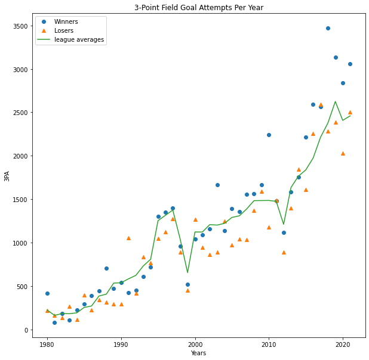

```python
# miscstats and leaguestats contain the averages of all the data presented for each season
#Leaguestats
#3P => 3-Point Field Goals
#3PA => 3-Point Field Goal Attempts
#3P% => 3-Point Field Goal Percentage
# FGA => Field Goal Average
# FG% => Field Goal Percentage

YrHiRank = []
YrLoRank = []
fig1, ax = plt.subplots()
for i in range(len(miscstats)):
    # Because miscstats sorts by the team's rank in the season, we can pull the
    # highest ranking team's information for each season by grabbing the head of that
    # season's dataframe
    head = miscstats[i][0].head(1)['Team']
    YrHiRank.append(head[0])
    for i in miscstats[i][0]['Team']:
        # We use a similar approach to what was described above in order to pull
        # the lowest ranking team
        if i != 'League Average':
            tail = i
    YrLoRank.append(tail)
#print(YrLoRank)
years = []
HiStat = []
LoStat = []
for i in range(1980,2022):
    years.append(i)
ssn3pa = []
for i in range(len(leaguestats)):
    #We then plot the average, the highest ranking team, and the lowest ranking team
    for j in leaguestats[i][0]['Team']:
        if j == YrHiRank[i]:
            stat = leaguestats[i][0][leaguestats[i][0]['Team'] == j]
            HiStat.append(float(stat['3PA']))

        if j == YrLoRank[i]:
            stat = leaguestats[i][0][leaguestats[i][0]['Team'] == j]
            LoStat.append(float(stat['3PA']))

    leagueAttmptStat = float(leaguestats[i][0]["3PA"].tail(1))
    ssn3pa.append(leagueAttmptStat)

fig1.set_size_inches(10, 10, forward=True)
ax.plot(years,HiStat,'o')
ax.plot(years,LoStat,'^')
ax.plot(years,ssn3pa)
plt.title('3-Point Field Goal Attempts Per Year')
plt.xlabel('Years')
plt.ylabel('3PA')
ax.legend(['Winners','Losers','league averages'])
```

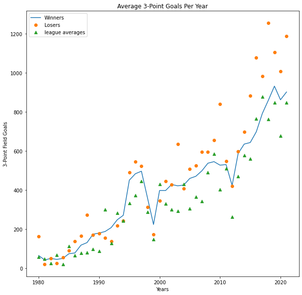

```python
ssn3p = []
HiStat = []
LoStat = []
for i in range(len(leaguestats)):
    for j in leaguestats[i][0]['Team']:
        if j == YrHiRank[i]:
            stat = leaguestats[i][0][leaguestats[i][0]['Team'] == j]
            HiStat.append(float(stat['3P']))

        if j == YrLoRank[i]:
            stat = leaguestats[i][0][leaguestats[i][0]['Team'] == j]
            LoStat.append(float(stat['3P']))
    leagueAvrgG = float(leaguestats[i][0]["3P"].tail(1))
    ssn3p.append(leagueAvrgG)
#print(years)
#print(ssn3pa)


fig1, ax = plt.subplots()
fig1.set_size_inches(10, 10, forward=True)
ax.plot(years,ssn3p)
ax.plot(years,HiStat,'o')
ax.plot(years,LoStat,'^')
plt.title('Average 3-Point Goals Per Year')
plt.ylabel('3-Point Field Goals')
plt.xlabel('Years')
ax.legend(['Winners','Losers','league averages'])
```

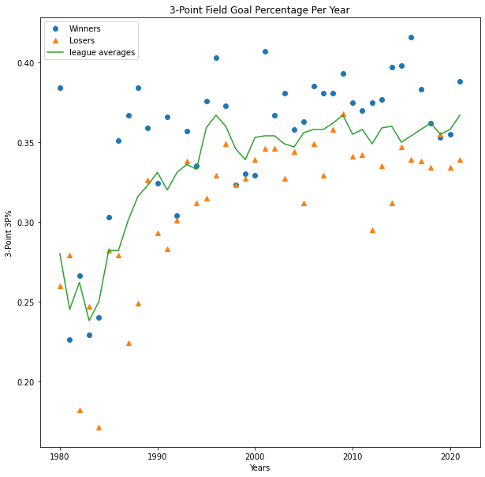

```python
ssn3pperc = []
HiStat = []
LoStat = []
for i in range(len(leaguestats)):
    for j in leaguestats[i][0]['Team']:
        if j == YrHiRank[i]:
            stat = leaguestats[i][0][leaguestats[i][0]['Team'] == j]
            HiStat.append(float(stat['3P%']))

        if j == YrLoRank[i]:
            stat = leaguestats[i][0][leaguestats[i][0]['Team'] == j]
            LoStat.append(float(stat['3P%']))
    leagueAvrgPerc = float(leaguestats[i][0]["3P%"].tail(1))
    ssn3pperc.append(leagueAvrgPerc)

fig1, ax = plt.subplots()
fig1.set_size_inches(10, 10, forward=True)
ax.plot(years,HiStat,'o')
ax.plot(years,LoStat,'^')
ax.plot(years,ssn3pperc)
plt.title('3-Point Field Goal Percentage Per Year')
plt.ylabel('3-Point 3P%')
plt.xlabel('Years')
ax.legend(['Winners','Losers','league averages'])
```

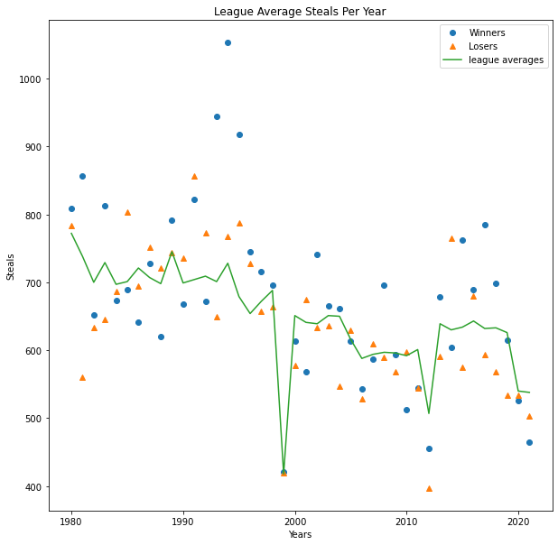

```python
SznStat = []
HiStat = []
LoStat = []
for i in range(len(leaguestats)):
    for j in leaguestats[i][0]['Team']:
        if j == YrHiRank[i]:
            stat = leaguestats[i][0][leaguestats[i][0]['Team'] == j]
            HiStat.append(float(stat['STL']))

        if j == YrLoRank[i]:
            stat = leaguestats[i][0][leaguestats[i][0]['Team'] == j]
            LoStat.append(float(stat['STL']))
    leagueAvrgPerc = float(leaguestats[i][0]["STL"].tail(1))
    SznStat.append(leagueAvrgPerc)

fig1, ax = plt.subplots()
fig1.set_size_inches(10, 10, forward=True)
ax.plot(years,HiStat,'o')
ax.plot(years,LoStat,'^')
ax.plot(years,SznStat)
plt.title('League Average Steals Per Year')
plt.ylabel('Steals')
plt.xlabel('Years')
ax.legend(['Winners','Losers','league averages'])
```

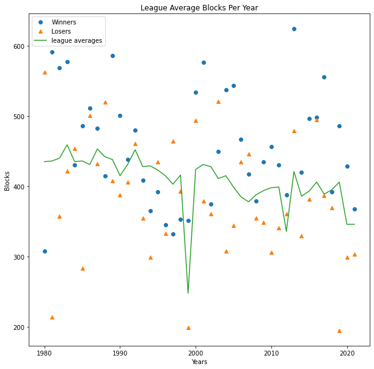

```python
SznStat = []
HiStat = []
LoStat = []
for i in range(len(leaguestats)):
    for j in leaguestats[i][0]['Team']:
        if j == YrHiRank[i]:
            stat = leaguestats[i][0][leaguestats[i][0]['Team'] == j]
            HiStat.append(float(stat['BLK']))

        if j == YrLoRank[i]:
            stat = leaguestats[i][0][leaguestats[i][0]['Team'] == j]
            LoStat.append(float(stat['BLK']))
    leagueAvrgPerc = float(leaguestats[i][0]["BLK"].tail(1))
    SznStat.append(leagueAvrgPerc)

fig1, ax = plt.subplots()
fig1.set_size_inches(10, 10, forward=True)
ax.plot(years,HiStat,'o')
ax.plot(years,LoStat,'^')
ax.plot(years,SznStat)
plt.title('League Average Blocks Per Year')
plt.ylabel('Blocks')
plt.xlabel('Years')
ax.legend(['Winners','Losers','league averages'])
```

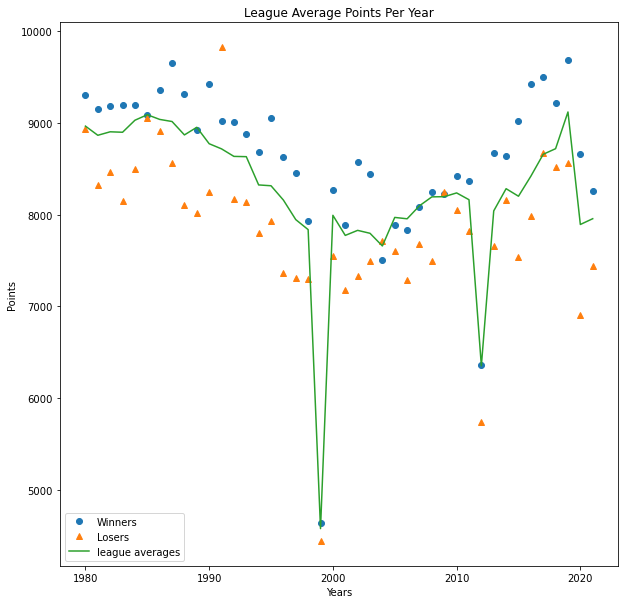

```python
SznStat = []
HiStat = []
LoStat = []
for i in range(len(leaguestats)):
    for j in leaguestats[i][0]['Team']:
        if j == YrHiRank[i]:
            stat = leaguestats[i][0][leaguestats[i][0]['Team'] == j]
            HiStat.append(float(stat['PTS']))

        if j == YrLoRank[i]:
            stat = leaguestats[i][0][leaguestats[i][0]['Team'] == j]
            LoStat.append(float(stat['PTS']))
    leagueAvrgPerc = float(leaguestats[i][0]["PTS"].tail(1))
    SznStat.append(leagueAvrgPerc)

fig1, ax = plt.subplots()
fig1.set_size_inches(10, 10, forward=True)
ax.plot(years,HiStat,'o')
ax.plot(years,LoStat,'^')
ax.plot(years,SznStat)
plt.title('League Average Points Per Year')
plt.ylabel('Points')
plt.xlabel('Years')
ax.legend(['Winners','Losers','league averages'])
```

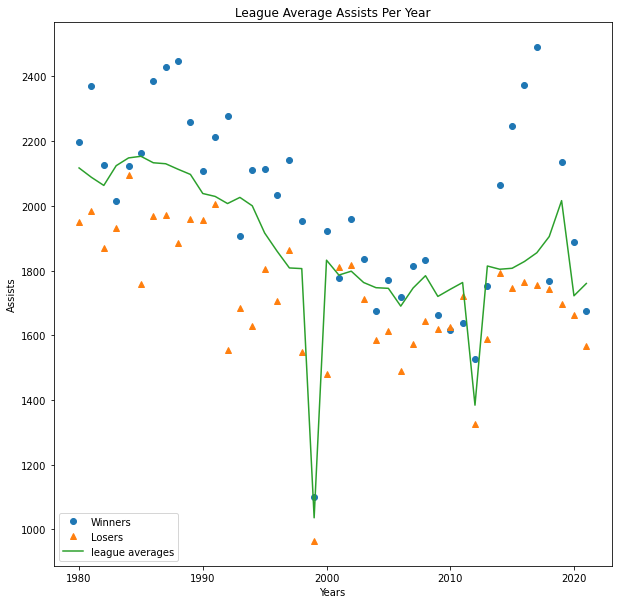

```python
SznStat = []
HiStat = []
LoStat = []
for i in range(len(leaguestats)):
    for j in leaguestats[i][0]['Team']:
        if j == YrHiRank[i]:
            stat = leaguestats[i][0][leaguestats[i][0]['Team'] == j]
            HiStat.append(float(stat['AST']))

        if j == YrLoRank[i]:
            stat = leaguestats[i][0][leaguestats[i][0]['Team'] == j]
            LoStat.append(float(stat['AST']))
    leagueAvrgPerc = float(leaguestats[i][0]["AST"].tail(1))
    SznStat.append(leagueAvrgPerc)

fig1, ax = plt.subplots()
fig1.set_size_inches(10, 10, forward=True)
ax.plot(years,HiStat,'o')
ax.plot(years,LoStat,'^')
ax.plot(years,SznStat)
plt.title('League Average Assists Per Year')
plt.ylabel('Assists')
plt.xlabel('Years')
ax.legend(['Winners','Losers','league averages'])
```

### Modifying our Approach

In order to avoid having a skew in our data, we decided to change our approach to being per game. That will allow us to view the league average per game, which would not be as affected by the lockout. However, it's important to note that although the data is then normalized by the per game approach, it does not change that the players themselves might have been affected by the lockout, which may be reflected by a change in performance during that season.

```python
baseurl ="https://www.basketball-reference.com/leagues/NBA_"
yearurl= 1980
endurl = ".html"
pergamestats = []
while (yearurl < 2022):
    r = requests.get(baseurl + str(yearurl) + endurl)
    soup = BeautifulSoup(r.text, 'lxml')
    commentedout = []
    for comment in soup.find_all(text = lambda text:isinstance(text,Comment)):
        commentedout.append(comment)
        #print(comment)
    for element in commentedout:
        if str(element).startswith('\n\n<div class="table_container" id="div_team-stats-per_game">'):
            #print(commentedout.index(element))
            correctindex = commentedout.index(element)
    newsoup = BeautifulSoup(commentedout[correctindex], 'html.parser' )
    pergamestats.append(pd.read_html(str(newsoup).replace("*",'')))
    yearurl+=1
```

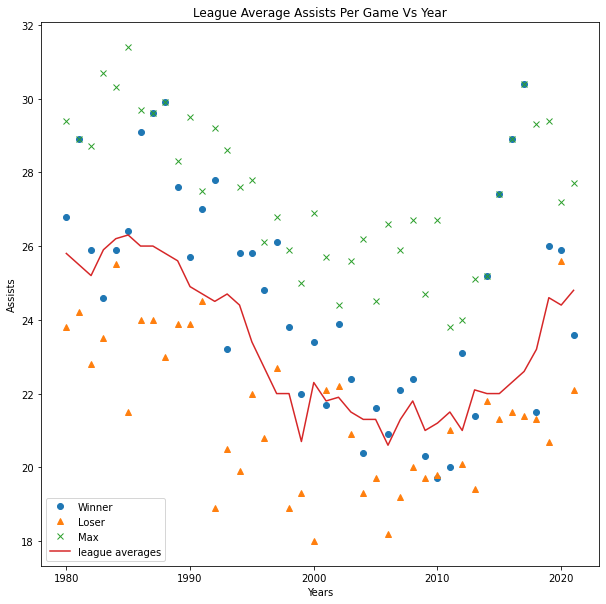

```python
SznStat = []
HiStat = []
LoStat = []
yrMax = []
for i in range(len(pergamestats)):
    for j in pergamestats[i][0]['Team']:
        if j == YrHiRank[i]:
            stat = pergamestats[i][0][pergamestats[i][0]['Team'] == j]
            HiStat.append(float(stat['AST']))

        if j == YrLoRank[i]:
            stat = pergamestats[i][0][pergamestats[i][0]['Team'] == j]
            LoStat.append(float(stat['AST']))
    leagueAvrgPerc = float(pergamestats[i][0]["AST"].tail(1))
    SznStat.append(leagueAvrgPerc)
    yrMax.append(pergamestats[i][0]['AST'].max())


fig1, ax = plt.subplots()
fig1.set_size_inches(10, 10, forward=True)
ax.plot(years,HiStat,'o')
ax.plot(years,LoStat,'^')
ax.plot(years,yrMax,'x')

ax.plot(years,SznStat)
plt.title('League Average Assists Per Game Vs Year')
plt.ylabel('Assists')
plt.xlabel('Years')
ax.legend(['Winner','Loser','Max','league averages'])
```

## Writeup note: Be sure to mention that we decided show the max (which represents the number of assists/blocks/whatever is being mentioned, for the team that had the highest of that statistic, NOT the winning team.)

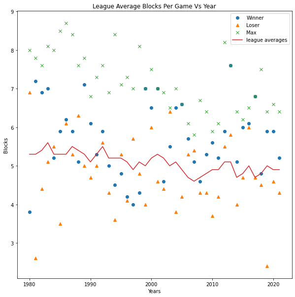

```python
SznStat = []
HiStat = []
LoStat = []
yrMax = []
for i in range(len(pergamestats)):
    for j in pergamestats[i][0]['Team']:
        if j == YrHiRank[i]:
            stat = pergamestats[i][0][pergamestats[i][0]['Team'] == j]
            HiStat.append(float(stat['BLK']))

        if j == YrLoRank[i]:
            stat = pergamestats[i][0][pergamestats[i][0]['Team'] == j]
            LoStat.append(float(stat['BLK']))
    leagueAvrgPerc = float(pergamestats[i][0]["BLK"].tail(1))
    SznStat.append(leagueAvrgPerc)
    yrMax.append(pergamestats[i][0]['BLK'].max())


fig1, ax = plt.subplots()
fig1.set_size_inches(10, 10, forward=True)
ax.plot(years,HiStat,'o')
ax.plot(years,LoStat,'^')
ax.plot(years,yrMax,'x')
ax.plot(years,SznStat)
plt.title('League Average Blocks Per Game Vs Year')
plt.ylabel('Blocks')
plt.xlabel('Years')
ax.legend(['Winner','Loser','Max','league averages'])
```

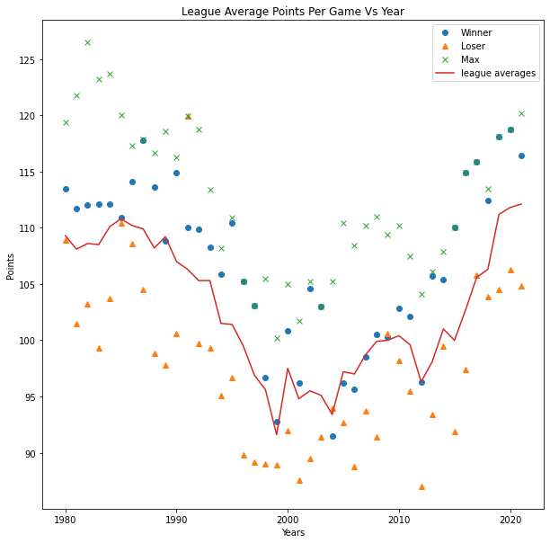

```python
SznStat = []
HiStat = []
LoStat = []
yrMax = []
for i in range(len(pergamestats)):
    for j in pergamestats[i][0]['Team']:
        if j == YrHiRank[i]:
            stat = pergamestats[i][0][pergamestats[i][0]['Team'] == j]
            HiStat.append(float(stat['PTS']))

        if j == YrLoRank[i]:
            stat = pergamestats[i][0][pergamestats[i][0]['Team'] == j]
            LoStat.append(float(stat['PTS']))
    leagueAvrgPerc = float(pergamestats[i][0]["PTS"].tail(1))
    SznStat.append(leagueAvrgPerc)
    yrMax.append(pergamestats[i][0]['PTS'].max())


fig1, ax = plt.subplots()
fig1.set_size_inches(10, 10, forward=True)
ax.plot(years,HiStat,'o')
ax.plot(years,LoStat,'^')
ax.plot(years,yrMax,'x')
ax.plot(years,SznStat)
plt.title('League Average Points Per Game Vs Year')
plt.ylabel('Points')
plt.xlabel('Years')
ax.legend(['Winner','Loser','Max','league averages'])
```

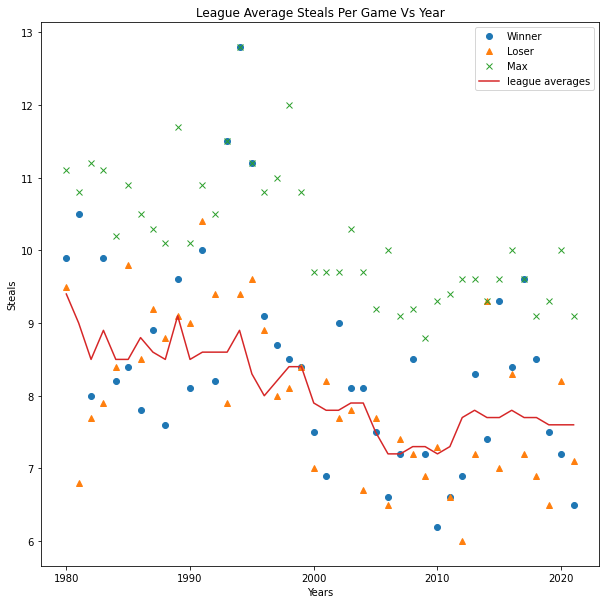

```python
SznStat = []
HiStat = []
LoStat = []
yrMax = []
for i in range(len(pergamestats)):
    for j in pergamestats[i][0]['Team']:
        if j == YrHiRank[i]:
            stat = pergamestats[i][0][pergamestats[i][0]['Team'] == j]
            HiStat.append(float(stat['STL']))

        if j == YrLoRank[i]:
            stat = pergamestats[i][0][pergamestats[i][0]['Team'] == j]
            LoStat.append(float(stat['STL']))
    leagueAvrgPerc = float(pergamestats[i][0]["STL"].tail(1))
    SznStat.append(leagueAvrgPerc)
    yrMax.append(pergamestats[i][0]['STL'].max())



fig1, ax = plt.subplots()
fig1.set_size_inches(10, 10, forward=True)
ax.plot(years,HiStat,'o')
ax.plot(years,LoStat,'^')
ax.plot(years,yrMax,'x')
ax.plot(years,SznStat)
plt.title('League Average Steals Per Game Vs Year')
plt.ylabel('Steals')
plt.xlabel('Years')
ax.legend(['Winner','Loser','Max','league averages'])
```

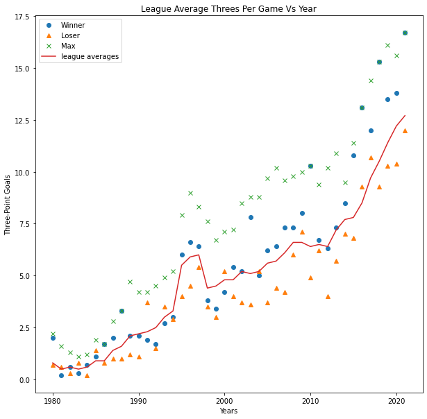

```python
#Look at this one. Makes it easier to talk about trends in the league because when we have
#The Highs and the lows being close together and not related to a teams performance
#changes very sharply after year 2010

SznStat = []
HiStat = []
LoStat = []
yrMax = []
for i in range(len(pergamestats)):
    for j in pergamestats[i][0]['Team']:
        if j == YrHiRank[i]:
            stat = pergamestats[i][0][pergamestats[i][0]['Team'] == j]
            HiStat.append(float(stat['3P']))

        if j == YrLoRank[i]:
            stat = pergamestats[i][0][pergamestats[i][0]['Team'] == j]
            LoStat.append(float(stat['3P']))
    leagueAvrgPerc = float(pergamestats[i][0]["3P"].tail(1))
    yrMax.append(pergamestats[i][0]['3P'].max())
    SznStat.append(leagueAvrgPerc)

fig1, ax = plt.subplots()
fig1.set_size_inches(10, 10, forward=True)
ax.plot(years,HiStat,'o')
ax.plot(years,LoStat,'^')
ax.plot(years,yrMax,'x')
ax.plot(years,SznStat)
plt.title('League Average Threes Per Game Vs Year')
plt.ylabel('Three-Point Goals')
plt.xlabel('Years')
ax.legend(['Winner','Loser','Max','league averages'])
```

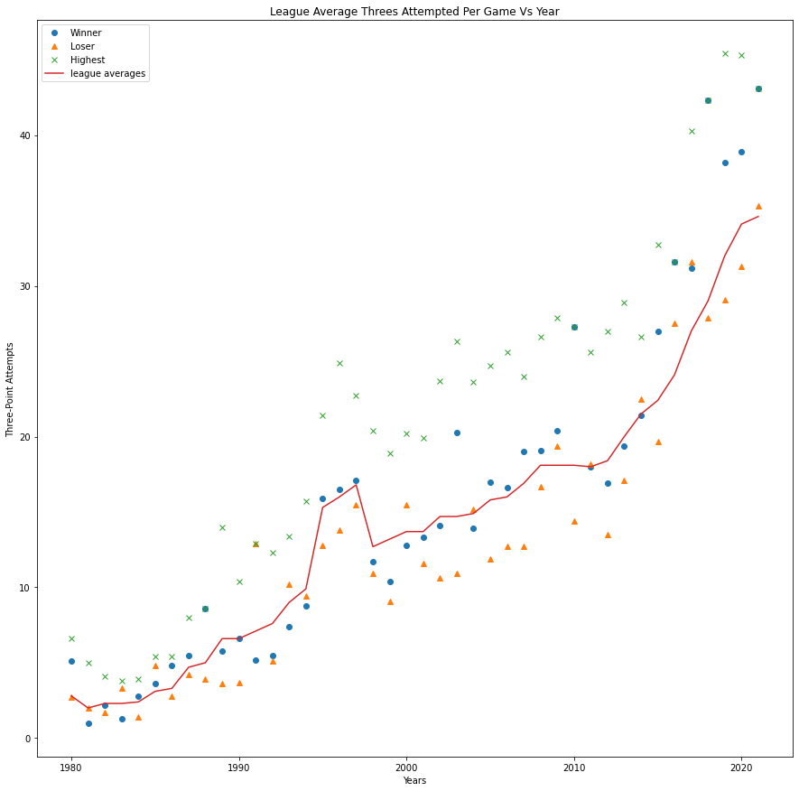

```python
SznStat = []
HiStat = []
LoStat = []
yrMax = []
for i in range(len(pergamestats)):
    for j in pergamestats[i][0]['Team']:
        if j == YrHiRank[i]:
            stat = pergamestats[i][0][pergamestats[i][0]['Team'] == j]
            HiStat.append(float(stat['3PA']))

        if j == YrLoRank[i]:
            stat = pergamestats[i][0][pergamestats[i][0]['Team'] == j]
            LoStat.append(float(stat['3PA']))

    leagueAvrgPerc = float(pergamestats[i][0]["3PA"].tail(1))
    SznStat.append(leagueAvrgPerc)
    yrMax.append(pergamestats[i][0]['3PA'].max())


fig1, ax = plt.subplots()
fig1.set_size_inches(15, 15, forward=True)
ax.plot(years,HiStat,'o')
ax.plot(years,LoStat,'^')
ax.plot(years,yrMax,'x')
ax.plot(years,SznStat)
plt.title('League Average Threes Attempted Per Game Vs Year')
plt.ylabel('Three-Point Attempts')
plt.xlabel('Years')
ax.legend(['Winner','Loser','Highest','league averages'])
```